# Risk Factor Analysis

## Outcome Variable

**Outcome Variable:** ever_co

## Predictor Variables

**Intervention Variable:** hdlvry

**Adjustment Set:**

- arm
- sex
- W_mage
- meducyrs
- feducyrs
- hhwealth_quart
- W_nrooms
- brthmon
- W_parity
- impsan
- delta_W_mage
- delta_meducyrs
- delta_feducyrs
- delta_hhwealth_quart
- delta_W_nrooms
- delta_brthmon
- delta_W_parity
- delta_impsan

## Stratifying Variables

The analysis was stratified on these variable(s):

- agecat
- studyid
- country

## Data Summary

| agecat | studyid | country | hdlvry | ever_co | n_cell | n |
| --- | --- | --- | --- | --- | --- | --- |
| 0-24 months | ki1000108-CMC-V-BCS-2002 | INDIA | 0 | 0 | 279 | 370 |
| 0-24 months | ki1000108-CMC-V-BCS-2002 | INDIA | 0 | 1 | 83 | 370 |
| 0-24 months | ki1000108-CMC-V-BCS-2002 | INDIA | 1 | 0 | 7 | 370 |
| 0-24 months | ki1000108-CMC-V-BCS-2002 | INDIA | 1 | 1 | 1 | 370 |
| 0-24 months | ki1000108-IRC | INDIA | 0 | 0 | 328 | 410 |
| 0-24 months | ki1000108-IRC | INDIA | 0 | 1 | 74 | 410 |
| 0-24 months | ki1000108-IRC | INDIA | 1 | 0 | 6 | 410 |
| 0-24 months | ki1000108-IRC | INDIA | 1 | 1 | 2 | 410 |
| 0-24 months | ki1000109-EE | PAKISTAN | 0 | 0 | 160 | 377 |
| 0-24 months | ki1000109-EE | PAKISTAN | 0 | 1 | 93 | 377 |
| 0-24 months | ki1000109-EE | PAKISTAN | 1 | 0 | 74 | 377 |
| 0-24 months | ki1000109-EE | PAKISTAN | 1 | 1 | 50 | 377 |
| 0-24 months | ki1000304b-SAS-CompFeed | INDIA | 0 | 0 | 140 | 1232 |
| 0-24 months | ki1000304b-SAS-CompFeed | INDIA | 0 | 1 | 24 | 1232 |
| 0-24 months | ki1000304b-SAS-CompFeed | INDIA | 1 | 0 | 795 | 1232 |
| 0-24 months | ki1000304b-SAS-CompFeed | INDIA | 1 | 1 | 273 | 1232 |
| 0-24 months | ki1000304b-SAS-FoodSuppl | INDIA | 0 | 0 | 55 | 418 |
| 0-24 months | ki1000304b-SAS-FoodSuppl | INDIA | 0 | 1 | 26 | 418 |
| 0-24 months | ki1000304b-SAS-FoodSuppl | INDIA | 1 | 0 | 208 | 418 |
| 0-24 months | ki1000304b-SAS-FoodSuppl | INDIA | 1 | 1 | 129 | 418 |
| 0-24 months | ki1017093b-PROVIDE | BANGLADESH | 0 | 0 | 456 | 700 |
| 0-24 months | ki1017093b-PROVIDE | BANGLADESH | 0 | 1 | 63 | 700 |
| 0-24 months | ki1017093b-PROVIDE | BANGLADESH | 1 | 0 | 154 | 700 |
| 0-24 months | ki1017093b-PROVIDE | BANGLADESH | 1 | 1 | 27 | 700 |
| 0-24 months | ki1017093c-NIH-Crypto | BANGLADESH | 0 | 0 | 545 | 758 |
| 0-24 months | ki1017093c-NIH-Crypto | BANGLADESH | 0 | 1 | 45 | 758 |
| 0-24 months | ki1017093c-NIH-Crypto | BANGLADESH | 1 | 0 | 142 | 758 |
| 0-24 months | ki1017093c-NIH-Crypto | BANGLADESH | 1 | 1 | 26 | 758 |
| 0-24 months | ki1066203-TanzaniaChild2 | TANZANIA, UNITED REPUBLIC OF | 0 | 0 | 2121 | 2274 |
| 0-24 months | ki1066203-TanzaniaChild2 | TANZANIA, UNITED REPUBLIC OF | 0 | 1 | 113 | 2274 |

[output cut: 114 more lines]

The following strata were considered:

- agecat: 0-24 months, studyid: ki1000108-CMC-V-BCS-2002, country: INDIA
- agecat: 0-24 months, studyid: ki1000108-IRC, country: INDIA
- agecat: 0-24 months, studyid: ki1000109-EE, country: PAKISTAN
- agecat: 0-24 months, studyid: ki1000304b-SAS-CompFeed, country: INDIA
- agecat: 0-24 months, studyid: ki1000304b-SAS-FoodSuppl, country: INDIA
- agecat: 0-24 months, studyid: ki1017093b-PROVIDE, country: BANGLADESH
- agecat: 0-24 months, studyid: ki1017093c-NIH-Crypto, country: BANGLADESH
- agecat: 0-24 months, studyid: ki1066203-TanzaniaChild2, country: TANZANIA, UNITED REPUBLIC OF
- agecat: 0-24 months, studyid: ki1113344-GMS-Nepal, country: NEPAL
- agecat: 0-24 months, studyid: ki1135781-COHORTS, country: INDIA
- agecat: 0-24 months, studyid: kiGH5241-JiVitA-3, country: BANGLADESH
- agecat: 0-24 months, studyid: kiGH5241-JiVitA-4, country: BANGLADESH
- agecat: 0-6 months, studyid: ki1000108-CMC-V-BCS-2002, country: INDIA
- agecat: 0-6 months, studyid: ki1000108-IRC, country: INDIA
- agecat: 0-6 months, studyid: ki1000109-EE, country: PAKISTAN
- agecat: 0-6 months, studyid: ki1000304b-SAS-CompFeed, country: INDIA
- agecat: 0-6 months, studyid: ki1000304b-SAS-FoodSuppl, country: INDIA
- agecat: 0-6 months, studyid: ki1017093b-PROVIDE, country: BANGLADESH
- agecat: 0-6 months, studyid: ki1017093c-NIH-Crypto, country: BANGLADESH
- agecat: 0-6 months, studyid: ki1066203-TanzaniaChild2, country: TANZANIA, UNITED REPUBLIC OF
- agecat: 0-6 months, studyid: ki1113344-GMS-Nepal, country: NEPAL
- agecat: 0-6 months, studyid: ki1135781-COHORTS, country: INDIA
- agecat: 0-6 months, studyid: kiGH5241-JiVitA-3, country: BANGLADESH
- agecat: 0-6 months, studyid: kiGH5241-JiVitA-4, country: BANGLADESH
- agecat: 6-24 months, studyid: ki1000108-CMC-V-BCS-2002, country: INDIA
- agecat: 6-24 months, studyid: ki1000108-IRC, country: INDIA
- agecat: 6-24 months, studyid: ki1000109-EE, country: PAKISTAN
- agecat: 6-24 months, studyid: ki1000304b-SAS-CompFeed, country: INDIA
- agecat: 6-24 months, studyid: ki1000304b-SAS-FoodSuppl, country: INDIA
- agecat: 6-24 months, studyid: ki1017093b-PROVIDE, country: BANGLADESH
- agecat: 6-24 months, studyid: ki1017093c-NIH-Crypto, country: BANGLADESH
- agecat: 6-24 months, studyid: ki1066203-TanzaniaChild2, country: TANZANIA, UNITED REPUBLIC OF
- agecat: 6-24 months, studyid: ki1113344-GMS-Nepal, country: NEPAL
- agecat: 6-24 months, studyid: ki1135781-COHORTS, country: INDIA
- agecat: 6-24 months, studyid: kiGH5241-JiVitA-3, country: BANGLADESH
- agecat: 6-24 months, studyid: kiGH5241-JiVitA-4, country: BANGLADESH

### Dropped Strata

Some strata were dropped due to rare outcomes:

- agecat: 0-24 months, studyid: ki1000108-CMC-V-BCS-2002, country: INDIA
- agecat: 0-24 months, studyid: ki1000108-IRC, country: INDIA
- agecat: 0-24 months, studyid: ki1066203-TanzaniaChild2, country: TANZANIA, UNITED REPUBLIC OF
- agecat: 0-24 months, studyid: kiGH5241-JiVitA-3, country: BANGLADESH
- agecat: 0-6 months, studyid: ki1000108-CMC-V-BCS-2002, country: INDIA
- agecat: 0-6 months, studyid: ki1000108-IRC, country: INDIA
- agecat: 0-6 months, studyid: ki1000304b-SAS-CompFeed, country: INDIA
- agecat: 0-6 months, studyid: ki1000304b-SAS-FoodSuppl, country: INDIA
- agecat: 0-6 months, studyid: ki1066203-TanzaniaChild2, country: TANZANIA, UNITED REPUBLIC OF
- agecat: 0-6 months, studyid: ki1113344-GMS-Nepal, country: NEPAL
- agecat: 0-6 months, studyid: kiGH5241-JiVitA-3, country: BANGLADESH
- agecat: 6-24 months, studyid: ki1000108-CMC-V-BCS-2002, country: INDIA
- agecat: 6-24 months, studyid: ki1000108-IRC, country: INDIA
- agecat: 6-24 months, studyid: ki1066203-TanzaniaChild2, country: TANZANIA, UNITED REPUBLIC OF
- agecat: 6-24 months, studyid: kiGH5241-JiVitA-3, country: BANGLADESH

## Methods Detail

We’re interested in the causal parameters $E[Y_a]$ for all values of $a \in \mathcal{A}$. These parameters represent the mean outcome if, possibly contrary to fact, we intervened to set all units to have $A=a$. Under the randomization and positivity assumptions, these are identified by the statistical parameters $\psi_a=E_W[E_{Y|A,W}(Y|A=a,W)]$. In addition, we’re interested in the mean of $Y$, $E[Y]$ under no intervention (the observed mean). We will estimate these parameters by using SuperLearner to fit the relevant likelihood factors – $E_{Y|A,W}(Y|A=a,W)$ and $p(A=a|W)$, and then updating our likelihood fit using a joint TMLE.

For unadjusted analyses ($W=\{\}$), initial likelihoods were estimated using Lrnr_glm to estimate the simple $E(Y|A)$ and Lrnr_mean to estimate $p(A)$. For adjusted analyses, a small library containing Lrnr_glmnet, Lrnr_xgboost, and Lrnr_mean was used.

Having estimated these parameters, we will then use the delta method to estimate relative risks and attributable risks relative to a prespecified baseline level of $A$.

# Results Detail

## Results Plots

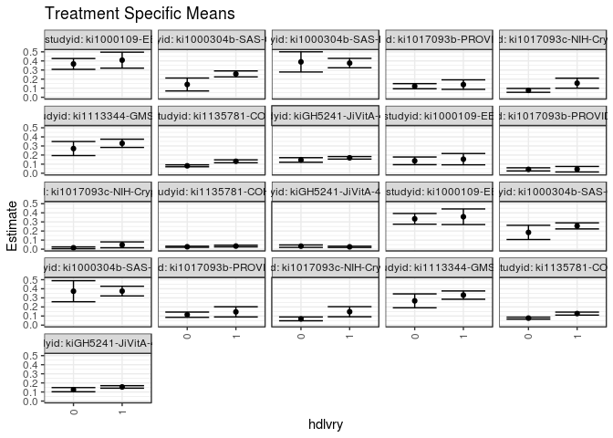

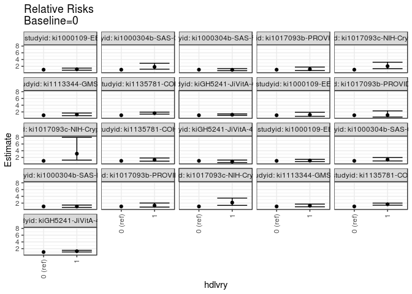

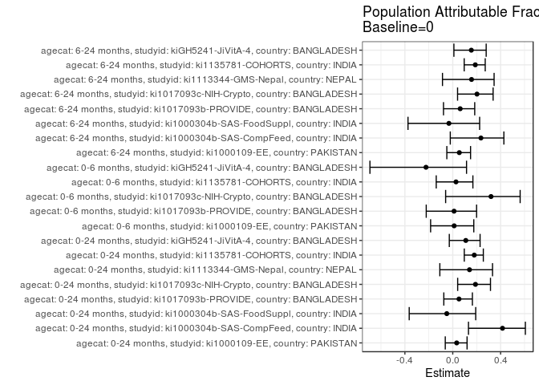

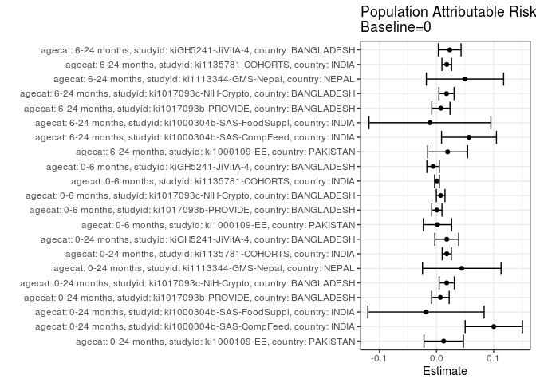

## Results Table

### Parameter: TSM

| agecat | studyid | country | intervention_level | baseline_level | estimate | ci_lower | ci_upper |
| --- | --- | --- | --- | --- | --- | --- | --- |
| 0-24 months | ki1000109-EE | PAKISTAN | 0 | NA | 0.3668556 | 0.3072683 | 0.4264429 |
| 0-24 months | ki1000109-EE | PAKISTAN | 1 | NA | 0.4083815 | 0.3206149 | 0.4961480 |
| 0-24 months | ki1000304b-SAS-CompFeed | INDIA | 0 | NA | 0.1408475 | 0.0696116 | 0.2120834 |
| 0-24 months | ki1000304b-SAS-CompFeed | INDIA | 1 | NA | 0.2571950 | 0.2245968 | 0.2897932 |
| 0-24 months | ki1000304b-SAS-FoodSuppl | INDIA | 0 | NA | 0.3893460 | 0.2783319 | 0.5003601 |
| 0-24 months | ki1000304b-SAS-FoodSuppl | INDIA | 1 | NA | 0.3762238 | 0.3241467 | 0.4283010 |
| 0-24 months | ki1017093b-PROVIDE | BANGLADESH | 0 | NA | 0.1218624 | 0.0937259 | 0.1499990 |
| 0-24 months | ki1017093b-PROVIDE | BANGLADESH | 1 | NA | 0.1395638 | 0.0872528 | 0.1918748 |
| 0-24 months | ki1017093c-NIH-Crypto | BANGLADESH | 0 | NA | 0.0758918 | 0.0544593 | 0.0973244 |
| 0-24 months | ki1017093c-NIH-Crypto | BANGLADESH | 1 | NA | 0.1551190 | 0.0999543 | 0.2102836 |
| 0-24 months | ki1113344-GMS-Nepal | NEPAL | 0 | NA | 0.2713353 | 0.1940651 | 0.3486054 |
| 0-24 months | ki1113344-GMS-Nepal | NEPAL | 1 | NA | 0.3291541 | 0.2838115 | 0.3744967 |
| 0-24 months | ki1135781-COHORTS | INDIA | 0 | NA | 0.0815539 | 0.0710029 | 0.0921048 |
| 0-24 months | ki1135781-COHORTS | INDIA | 1 | NA | 0.1312671 | 0.1151813 | 0.1473528 |
| 0-24 months | kiGH5241-JiVitA-4 | BANGLADESH | 0 | NA | 0.1458851 | 0.1208111 | 0.1709590 |
| 0-24 months | kiGH5241-JiVitA-4 | BANGLADESH | 1 | NA | 0.1695081 | 0.1554558 | 0.1835604 |
| 0-6 months | ki1000109-EE | PAKISTAN | 0 | NA | 0.1363172 | 0.0941759 | 0.1784585 |
| 0-6 months | ki1000109-EE | PAKISTAN | 1 | NA | 0.1546365 | 0.0922987 | 0.2169744 |
| 0-6 months | ki1017093b-PROVIDE | BANGLADESH | 0 | NA | 0.0423892 | 0.0250433 | 0.0597351 |
| 0-6 months | ki1017093b-PROVIDE | BANGLADESH | 1 | NA | 0.0441989 | 0.0142343 | 0.0741635 |
| 0-6 months | ki1017093c-NIH-Crypto | BANGLADESH | 0 | NA | 0.0152542 | 0.0053581 | 0.0251504 |
| 0-6 months | ki1017093c-NIH-Crypto | BANGLADESH | 1 | NA | 0.0476190 | 0.0153953 | 0.0798428 |
| 0-6 months | ki1135781-COHORTS | INDIA | 0 | NA | 0.0264498 | 0.0203313 | 0.0325682 |
| 0-6 months | ki1135781-COHORTS | INDIA | 1 | NA | 0.0342749 | 0.0250474 | 0.0435025 |
| 0-6 months | kiGH5241-JiVitA-4 | BANGLADESH | 0 | NA | 0.0332271 | 0.0198764 | 0.0465779 |
| 0-6 months | kiGH5241-JiVitA-4 | BANGLADESH | 1 | NA | 0.0257795 | 0.0189087 | 0.0326504 |
| 6-24 months | ki1000109-EE | PAKISTAN | 0 | NA | 0.3337299 | 0.2747529 | 0.3927068 |
| 6-24 months | ki1000109-EE | PAKISTAN | 1 | NA | 0.3568049 | 0.2708761 | 0.4427336 |
| 6-24 months | ki1000304b-SAS-CompFeed | INDIA | 0 | NA | 0.1843486 | 0.1059489 | 0.2627482 |
| 6-24 months | ki1000304b-SAS-CompFeed | INDIA | 1 | NA | 0.2562194 | 0.2228711 | 0.2895678 |
| 6-24 months | ki1000304b-SAS-FoodSuppl | INDIA | 0 | NA | 0.3732063 | 0.2574856 | 0.4889270 |
| 6-24 months | ki1000304b-SAS-FoodSuppl | INDIA | 1 | NA | 0.3743746 | 0.3211516 | 0.4275976 |
| 6-24 months | ki1017093b-PROVIDE | BANGLADESH | 0 | NA | 0.1145549 | 0.0855513 | 0.1435585 |
| 6-24 months | ki1017093b-PROVIDE | BANGLADESH | 1 | NA | 0.1458337 | 0.0899238 | 0.2017435 |
| 6-24 months | ki1017093c-NIH-Crypto | BANGLADESH | 0 | NA | 0.0688233 | 0.0479354 | 0.0897112 |
| 6-24 months | ki1017093c-NIH-Crypto | BANGLADESH | 1 | NA | 0.1473705 | 0.0920124 | 0.2027285 |
| 6-24 months | ki1113344-GMS-Nepal | NEPAL | 0 | NA | 0.2671790 | 0.1907351 | 0.3436229 |
| 6-24 months | ki1113344-GMS-Nepal | NEPAL | 1 | NA | 0.3303722 | 0.2848902 | 0.3758541 |
| 6-24 months | ki1135781-COHORTS | INDIA | 0 | NA | 0.0768938 | 0.0660672 | 0.0877204 |
| 6-24 months | ki1135781-COHORTS | INDIA | 1 | NA | 0.1269252 | 0.1105232 | 0.1433273 |
| 6-24 months | kiGH5241-JiVitA-4 | BANGLADESH | 0 | NA | 0.1252551 | 0.1024038 | 0.1481064 |
| 6-24 months | kiGH5241-JiVitA-4 | BANGLADESH | 1 | NA | 0.1556101 | 0.1417936 | 0.1694267 |

### Parameter: E(Y)

| agecat | studyid | country | intervention_level | baseline_level | estimate | ci_lower | ci_upper |
| --- | --- | --- | --- | --- | --- | --- | --- |
| 0-24 months | ki1000109-EE | PAKISTAN | NA | NA | 0.3793103 | 0.3302660 | 0.4283547 |
| 0-24 months | ki1000304b-SAS-CompFeed | INDIA | NA | NA | 0.2410714 | 0.1975050 | 0.2846379 |
| 0-24 months | ki1000304b-SAS-FoodSuppl | INDIA | NA | NA | 0.3708134 | 0.3244530 | 0.4171738 |
| 0-24 months | ki1017093b-PROVIDE | BANGLADESH | NA | NA | 0.1285714 | 0.1037574 | 0.1533855 |
| 0-24 months | ki1017093c-NIH-Crypto | BANGLADESH | NA | NA | 0.0936675 | 0.0729118 | 0.1144233 |
| 0-24 months | ki1113344-GMS-Nepal | NEPAL | NA | NA | 0.3155080 | 0.2770184 | 0.3539976 |
| 0-24 months | ki1135781-COHORTS | INDIA | NA | NA | 0.0994301 | 0.0912079 | 0.1076524 |
| 0-24 months | kiGH5241-JiVitA-4 | BANGLADESH | NA | NA | 0.1637414 | 0.1510998 | 0.1763830 |
| 0-6 months | ki1000109-EE | PAKISTAN | NA | NA | 0.1379310 | 0.1030768 | 0.1727853 |
| 0-6 months | ki1017093b-PROVIDE | BANGLADESH | NA | NA | 0.0428571 | 0.0278427 | 0.0578716 |
| 0-6 months | ki1017093c-NIH-Crypto | BANGLADESH | NA | NA | 0.0224274 | 0.0118796 | 0.0329753 |
| 0-6 months | ki1135781-COHORTS | INDIA | NA | NA | 0.0271860 | 0.0226456 | 0.0317265 |
| 0-6 months | kiGH5241-JiVitA-4 | BANGLADESH | NA | NA | 0.0271544 | 0.0212424 | 0.0330664 |
| 6-24 months | ki1000109-EE | PAKISTAN | NA | NA | 0.3530997 | 0.3044013 | 0.4017981 |
| 6-24 months | ki1000304b-SAS-CompFeed | INDIA | NA | NA | 0.2411348 | 0.1953341 | 0.2869354 |
| 6-24 months | ki1000304b-SAS-FoodSuppl | INDIA | NA | NA | 0.3615960 | 0.3145115 | 0.4086805 |
| 6-24 months | ki1017093b-PROVIDE | BANGLADESH | NA | NA | 0.1221498 | 0.0962275 | 0.1480722 |
| 6-24 months | ki1017093c-NIH-Crypto | BANGLADESH | NA | NA | 0.0863014 | 0.0659171 | 0.1066856 |
| 6-24 months | ki1113344-GMS-Nepal | NEPAL | NA | NA | 0.3169399 | 0.2779838 | 0.3558960 |
| 6-24 months | ki1135781-COHORTS | INDIA | NA | NA | 0.0947257 | 0.0863884 | 0.1030631 |
| 6-24 months | kiGH5241-JiVitA-4 | BANGLADESH | NA | NA | 0.1482636 | 0.1364361 | 0.1600910 |

### Parameter: RR

| agecat | studyid | country | intervention_level | baseline_level | estimate | ci_lower | ci_upper |
| --- | --- | --- | --- | --- | --- | --- | --- |
| 0-24 months | ki1000109-EE | PAKISTAN | 0 | 0 | 1.0000000 | 1.0000000 | 1.000000 |
| 0-24 months | ki1000109-EE | PAKISTAN | 1 | 0 | 1.1131939 | 0.8502661 | 1.457427 |
| 0-24 months | ki1000304b-SAS-CompFeed | INDIA | 0 | 0 | 1.0000000 | 1.0000000 | 1.000000 |
| 0-24 months | ki1000304b-SAS-CompFeed | INDIA | 1 | 0 | 1.8260524 | 1.1480311 | 2.904510 |
| 0-24 months | ki1000304b-SAS-FoodSuppl | INDIA | 0 | 0 | 1.0000000 | 1.0000000 | 1.000000 |
| 0-24 months | ki1000304b-SAS-FoodSuppl | INDIA | 1 | 0 | 0.9662969 | 0.7039626 | 1.326391 |
| 0-24 months | ki1017093b-PROVIDE | BANGLADESH | 0 | 0 | 1.0000000 | 1.0000000 | 1.000000 |
| 0-24 months | ki1017093b-PROVIDE | BANGLADESH | 1 | 0 | 1.1452572 | 0.7371687 | 1.779259 |
| 0-24 months | ki1017093c-NIH-Crypto | BANGLADESH | 0 | 0 | 1.0000000 | 1.0000000 | 1.000000 |
| 0-24 months | ki1017093c-NIH-Crypto | BANGLADESH | 1 | 0 | 2.0439479 | 1.2977055 | 3.219315 |
| 0-24 months | ki1113344-GMS-Nepal | NEPAL | 0 | 0 | 1.0000000 | 1.0000000 | 1.000000 |
| 0-24 months | ki1113344-GMS-Nepal | NEPAL | 1 | 0 | 1.2130901 | 0.8837992 | 1.665070 |
| 0-24 months | ki1135781-COHORTS | INDIA | 0 | 0 | 1.0000000 | 1.0000000 | 1.000000 |
| 0-24 months | ki1135781-COHORTS | INDIA | 1 | 0 | 1.6095751 | 1.3476244 | 1.922444 |
| 0-24 months | kiGH5241-JiVitA-4 | BANGLADESH | 0 | 0 | 1.0000000 | 1.0000000 | 1.000000 |
| 0-24 months | kiGH5241-JiVitA-4 | BANGLADESH | 1 | 0 | 1.1619292 | 0.9642889 | 1.400078 |
| 0-6 months | ki1000109-EE | PAKISTAN | 0 | 0 | 1.0000000 | 1.0000000 | 1.000000 |
| 0-6 months | ki1000109-EE | PAKISTAN | 1 | 0 | 1.1343876 | 0.6821517 | 1.886436 |
| 0-6 months | ki1017093b-PROVIDE | BANGLADESH | 0 | 0 | 1.0000000 | 1.0000000 | 1.000000 |
| 0-6 months | ki1017093b-PROVIDE | BANGLADESH | 1 | 0 | 1.0426921 | 0.4723343 | 2.301774 |
| 0-6 months | ki1017093c-NIH-Crypto | BANGLADESH | 0 | 0 | 1.0000000 | 1.0000000 | 1.000000 |
| 0-6 months | ki1017093c-NIH-Crypto | BANGLADESH | 1 | 0 | 3.1216931 | 1.2225460 | 7.971044 |
| 0-6 months | ki1135781-COHORTS | INDIA | 0 | 0 | 1.0000000 | 1.0000000 | 1.000000 |
| 0-6 months | ki1135781-COHORTS | INDIA | 1 | 0 | 1.2958497 | 0.9084784 | 1.848395 |
| 0-6 months | kiGH5241-JiVitA-4 | BANGLADESH | 0 | 0 | 1.0000000 | 1.0000000 | 1.000000 |
| 0-6 months | kiGH5241-JiVitA-4 | BANGLADESH | 1 | 0 | 0.7758574 | 0.4863517 | 1.237694 |
| 6-24 months | ki1000109-EE | PAKISTAN | 0 | 0 | 1.0000000 | 1.0000000 | 1.000000 |
| 6-24 months | ki1000109-EE | PAKISTAN | 1 | 0 | 1.0691427 | 0.7929768 | 1.441488 |
| 6-24 months | ki1000304b-SAS-CompFeed | INDIA | 0 | 0 | 1.0000000 | 1.0000000 | 1.000000 |
| 6-24 months | ki1000304b-SAS-CompFeed | INDIA | 1 | 0 | 1.3898640 | 0.9763260 | 1.978562 |
| 6-24 months | ki1000304b-SAS-FoodSuppl | INDIA | 0 | 0 | 1.0000000 | 1.0000000 | 1.000000 |
| 6-24 months | ki1000304b-SAS-FoodSuppl | INDIA | 1 | 0 | 1.0031303 | 0.7135191 | 1.410292 |
| 6-24 months | ki1017093b-PROVIDE | BANGLADESH | 0 | 0 | 1.0000000 | 1.0000000 | 1.000000 |
| 6-24 months | ki1017093b-PROVIDE | BANGLADESH | 1 | 0 | 1.2730460 | 0.8044638 | 2.014567 |
| 6-24 months | ki1017093c-NIH-Crypto | BANGLADESH | 0 | 0 | 1.0000000 | 1.0000000 | 1.000000 |
| 6-24 months | ki1017093c-NIH-Crypto | BANGLADESH | 1 | 0 | 2.1412874 | 1.3196927 | 3.474378 |
| 6-24 months | ki1113344-GMS-Nepal | NEPAL | 0 | 0 | 1.0000000 | 1.0000000 | 1.000000 |
| 6-24 months | ki1113344-GMS-Nepal | NEPAL | 1 | 0 | 1.2365199 | 0.8996418 | 1.699545 |
| 6-24 months | ki1135781-COHORTS | INDIA | 0 | 0 | 1.0000000 | 1.0000000 | 1.000000 |
| 6-24 months | ki1135781-COHORTS | INDIA | 1 | 0 | 1.6506566 | 1.3644912 | 1.996838 |
| 6-24 months | kiGH5241-JiVitA-4 | BANGLADESH | 0 | 0 | 1.0000000 | 1.0000000 | 1.000000 |
| 6-24 months | kiGH5241-JiVitA-4 | BANGLADESH | 1 | 0 | 1.2423459 | 1.0146184 | 1.521186 |

### Parameter: PAR

| agecat | studyid | country | intervention_level | baseline_level | estimate | ci_lower | ci_upper |
| --- | --- | --- | --- | --- | --- | --- | --- |
| 0-24 months | ki1000109-EE | PAKISTAN | 0 | NA | 0.0124547 | -0.0220493 | 0.0469587 |
| 0-24 months | ki1000304b-SAS-CompFeed | INDIA | 0 | NA | 0.1002239 | 0.0500719 | 0.1503759 |
| 0-24 months | ki1000304b-SAS-FoodSuppl | INDIA | 0 | NA | -0.0185326 | -0.1203263 | 0.0832611 |
| 0-24 months | ki1017093b-PROVIDE | BANGLADESH | 0 | NA | 0.0067090 | -0.0086538 | 0.0220719 |
| 0-24 months | ki1017093c-NIH-Crypto | BANGLADESH | 0 | NA | 0.0177757 | 0.0045159 | 0.0310355 |
| 0-24 months | ki1113344-GMS-Nepal | NEPAL | 0 | NA | 0.0441728 | -0.0246053 | 0.1129508 |
| 0-24 months | ki1135781-COHORTS | INDIA | 0 | NA | 0.0178763 | 0.0098859 | 0.0258667 |
| 0-24 months | kiGH5241-JiVitA-4 | BANGLADESH | 0 | NA | 0.0178563 | -0.0030066 | 0.0387193 |
| 0-6 months | ki1000109-EE | PAKISTAN | 0 | NA | 0.0016138 | -0.0231493 | 0.0263769 |
| 0-6 months | ki1017093b-PROVIDE | BANGLADESH | 0 | NA | 0.0004679 | -0.0084848 | 0.0094207 |
| 0-6 months | ki1017093c-NIH-Crypto | BANGLADESH | 0 | NA | 0.0071732 | -0.0003591 | 0.0147055 |
| 0-6 months | ki1135781-COHORTS | INDIA | 0 | NA | 0.0007363 | -0.0034118 | 0.0048843 |
| 0-6 months | kiGH5241-JiVitA-4 | BANGLADESH | 0 | NA | -0.0060728 | -0.0170093 | 0.0048638 |
| 6-24 months | ki1000109-EE | PAKISTAN | 0 | NA | 0.0193699 | -0.0155639 | 0.0543036 |
| 6-24 months | ki1000304b-SAS-CompFeed | INDIA | 0 | NA | 0.0567862 | 0.0087036 | 0.1048688 |
| 6-24 months | ki1000304b-SAS-FoodSuppl | INDIA | 0 | NA | -0.0116103 | -0.1183712 | 0.0951506 |
| 6-24 months | ki1017093b-PROVIDE | BANGLADESH | 0 | NA | 0.0075949 | -0.0083837 | 0.0235736 |
| 6-24 months | ki1017093c-NIH-Crypto | BANGLADESH | 0 | NA | 0.0174781 | 0.0041721 | 0.0307840 |
| 6-24 months | ki1113344-GMS-Nepal | NEPAL | 0 | NA | 0.0497609 | -0.0178983 | 0.1174201 |
| 6-24 months | ki1135781-COHORTS | INDIA | 0 | NA | 0.0178319 | 0.0094104 | 0.0262535 |
| 6-24 months | kiGH5241-JiVitA-4 | BANGLADESH | 0 | NA | 0.0230085 | 0.0031218 | 0.0428952 |

### Parameter: PAF

| agecat | studyid | country | intervention_level | baseline_level | estimate | ci_lower | ci_upper |
| --- | --- | --- | --- | --- | --- | --- | --- |
| 0-24 months | ki1000109-EE | PAKISTAN | 0 | NA | 0.0328351 | -0.0625915 | 0.1196919 |
| 0-24 months | ki1000304b-SAS-CompFeed | INDIA | 0 | NA | 0.4157436 | 0.1314683 | 0.6069740 |
| 0-24 months | ki1000304b-SAS-FoodSuppl | INDIA | 0 | NA | -0.0499782 | -0.3639748 | 0.1917341 |
| 0-24 months | ki1017093b-PROVIDE | BANGLADESH | 0 | NA | 0.0521812 | -0.0747468 | 0.1641190 |
| 0-24 months | ki1017093c-NIH-Crypto | BANGLADESH | 0 | NA | 0.1897744 | 0.0411436 | 0.3153662 |
| 0-24 months | ki1113344-GMS-Nepal | NEPAL | 0 | NA | 0.1400052 | -0.1079643 | 0.3324775 |
| 0-24 months | ki1135781-COHORTS | INDIA | 0 | NA | 0.1797873 | 0.0963569 | 0.2555149 |
| 0-24 months | kiGH5241-JiVitA-4 | BANGLADESH | 0 | NA | 0.1090520 | -0.0288607 | 0.2284783 |
| 0-6 months | ki1000109-EE | PAKISTAN | 0 | NA | 0.0117003 | -0.1850950 | 0.1758161 |
| 0-6 months | ki1017093b-PROVIDE | BANGLADESH | 0 | NA | 0.0109184 | -0.2216378 | 0.1992043 |
| 0-6 months | ki1017093c-NIH-Crypto | BANGLADESH | 0 | NA | 0.3198405 | -0.0594838 | 0.5633562 |
| 0-6 months | ki1135781-COHORTS | INDIA | 0 | NA | 0.0270821 | -0.1381360 | 0.1683162 |
| 0-6 months | kiGH5241-JiVitA-4 | BANGLADESH | 0 | NA | -0.2236378 | -0.6922450 | 0.1152053 |
| 6-24 months | ki1000109-EE | PAKISTAN | 0 | NA | 0.0548566 | -0.0494821 | 0.1488221 |
| 6-24 months | ki1000304b-SAS-CompFeed | INDIA | 0 | NA | 0.2354957 | -0.0206254 | 0.4273444 |
| 6-24 months | ki1000304b-SAS-FoodSuppl | INDIA | 0 | NA | -0.0321085 | -0.3740831 | 0.2247573 |
| 6-24 months | ki1017093b-PROVIDE | BANGLADESH | 0 | NA | 0.0621773 | -0.0773844 | 0.1836605 |
| 6-24 months | ki1017093c-NIH-Crypto | BANGLADESH | 0 | NA | 0.2025236 | 0.0402795 | 0.3373398 |
| 6-24 months | ki1113344-GMS-Nepal | NEPAL | 0 | NA | 0.1570042 | -0.0858728 | 0.3455569 |
| 6-24 months | ki1135781-COHORTS | INDIA | 0 | NA | 0.1882482 | 0.0956346 | 0.2713774 |
| 6-24 months | kiGH5241-JiVitA-4 | BANGLADESH | 0 | NA | 0.1551864 | 0.0095583 | 0.2794023 |